# Topic 5: k-Nearest Neighbors (k-NN)

Distance-Based Classification and Model Selection

MS in Statistics for Data Science

UC3M, 2026

# 1 Introduction

In this notebook, we focus on **k-Nearest Neighbors (k-NN)**, a simple and powerful non-parametric classifier. We will study how distance metrics, scaling, and the choice of $k$ affect model behavior and performance.

```r
# Core packages
library(tidyverse)    # Data manipulation and visualization
library(class)        # k-NN implementation
library(caret)        # Model training and evaluation
library(pROC)         # ROC curve analysis

# Visualization
library(ggplot2)
library(patchwork)
library(viridis)

# Set seed for reproducibility
set.seed(42)
```

# 2 k-Nearest Neighbors for Classification

To practice with a classification example, we will use the iris dataset.

```r
# Load and explore the data
data(iris)
glimpse(iris)
```

```
## Rows: 150
## Columns: 5
## $ Sepal.Length <dbl> 5.1, 4.9, 4.7, 4.6, 5.0, 5.4, 4.6, 5.0, 4.4, 4.9, 5.4, 4.…
## $ Sepal.Width  <dbl> 3.5, 3.0, 3.2, 3.1, 3.6, 3.9, 3.4, 3.4, 2.9, 3.1, 3.7, 3.…
## $ Petal.Length <dbl> 1.4, 1.4, 1.3, 1.5, 1.4, 1.7, 1.4, 1.5, 1.4, 1.5, 1.5, 1.…
## $ Petal.Width  <dbl> 0.2, 0.2, 0.2, 0.2, 0.2, 0.4, 0.3, 0.2, 0.2, 0.1, 0.2, 0.…
## $ Species      <fct> setosa, setosa, setosa, setosa, setosa, setosa, setosa, s…
```

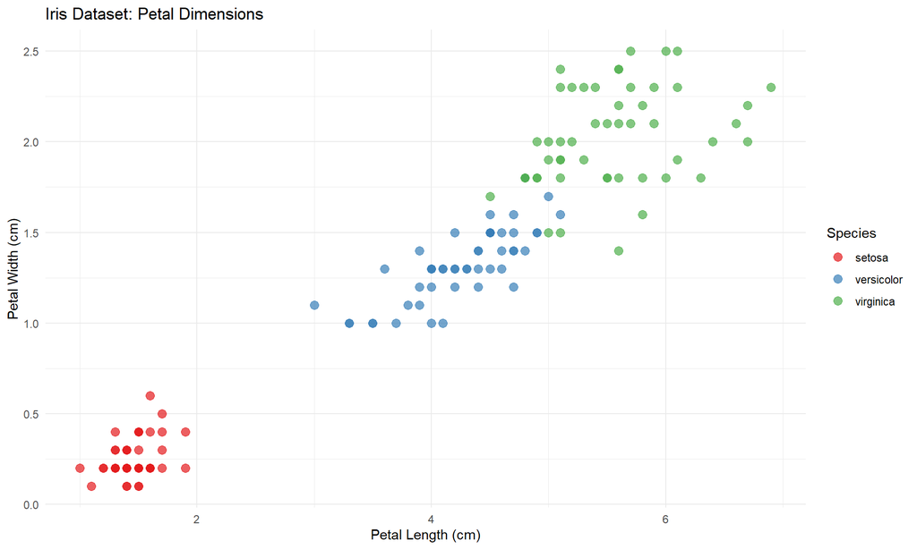

```r
# Pairwise scatter plots
ggplot(iris, aes(x = Petal.Length, y = Petal.Width, color = Species)) +
  geom_point(size = 3, alpha = 0.7) +
  labs(title = "Iris Dataset: Petal Dimensions",
       x = "Petal Length (cm)", y = "Petal Width (cm)") +
  theme_minimal() +
  scale_color_brewer(palette = "Set1")
```

```r
# Create train/test split
set.seed(123)
train_idx <- createDataPartition(iris$Species, p = 0.7, list = FALSE)
iris_train <- iris[train_idx, ]
iris_test <- iris[-train_idx, ]

cat("Training set:", nrow(iris_train), "samples\n")
```

```
## Training set: 105 samples
```

```r
cat("Test set:", nrow(iris_test), "samples\n")
```

```
## Test set: 45 samples
```

k-NN uses distances, so features with larger scales dominate the distance calculation. Therefore, we should scale the data as a first step. Remember to create the scale parameters using only the train data

```r
# Without scaling - distances dominated by large features
cat("Range before scaling:\n")
```

```
## Range before scaling:
```

```r
sapply(iris_train[, 1:4], range)
```

```
##      Sepal.Length Sepal.Width Petal.Length Petal.Width
## [1,]          4.3         2.0          1.1         0.1
## [2,]          7.9         4.1          6.9         2.5
```

```r
# With scaling
train_scaled <- scale(iris_train[, 1:4])
test_scaled <- scale(iris_test[, 1:4],
                     center = attr(train_scaled, "scaled:center"),
                     scale = attr(train_scaled, "scaled:scale"))

cat("\nRange after scaling:\n")
```

```
##
## Range after scaling:
```

```r
sapply(as.data.frame(train_scaled), range)
```

```
##      Sepal.Length Sepal.Width Petal.Length Petal.Width
## [1,]    -1.831159   -2.549028    -1.506600   -1.424966
## [2,]     2.407532    2.588638     1.759756    1.689443
```

## 2.1 Using k-NN and decision boundaries

Once we have our scaled data, we can use the `knn` function.

```r
# k-NN with k = 3
knn_pred_k3 <- knn(train = train_scaled,
                   test = test_scaled,
                   cl = iris_train$Species,
                   k = 3)

# Confusion matrix
confusionMatrix(knn_pred_k3, iris_test$Species)
```

```
## Confusion Matrix and Statistics
##
##             Reference
## Prediction   setosa versicolor virginica
##   setosa         15          0         0
##   versicolor      0         14         2
##   virginica       0          1        13
##
## Overall Statistics
##
##                Accuracy : 0.9333
##                  95% CI : (0.8173, 0.986)
##     No Information Rate : 0.3333
##     P-Value [Acc > NIR] : < 2.2e-16
##
##                   Kappa : 0.9
##
##  Mcnemar's Test P-Value : NA
##
## Statistics by Class:
##
##                      Class: setosa Class: versicolor Class: virginica
## Sensitivity                 1.0000            0.9333           0.8667
## Specificity                 1.0000            0.9333           0.9667
## Pos Pred Value              1.0000            0.8750           0.9286
## Neg Pred Value              1.0000            0.9655           0.9355
## Prevalence                  0.3333            0.3333           0.3333
## Detection Rate              0.3333            0.3111           0.2889
## Detection Prevalence        0.3333            0.3556           0.3111
## Balanced Accuracy           1.0000            0.9333           0.9167
```

To visualize the decision boundaries, we can create a grid of points using just 2 features, and get which class would be predicted at each element of the grid. This allows us to plot the ``backgroudn color’’.

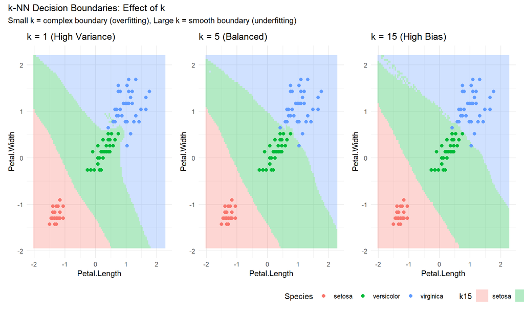

```r
# Create a grid for visualization (using 2 features)
x_range <- seq(min(train_scaled[, "Petal.Length"]) - 0.5,
               max(train_scaled[, "Petal.Length"]) + 0.5, length.out = 100)
y_range <- seq(min(train_scaled[, "Petal.Width"]) - 0.5,
               max(train_scaled[, "Petal.Width"]) + 0.5, length.out = 100)
grid <- expand.grid(Petal.Length = x_range, Petal.Width = y_range)

# Predictions on grid for different values of k
grid$k1 <- knn(train = train_scaled[, c("Petal.Length", "Petal.Width")],
               test = as.matrix(grid[, c("Petal.Length", "Petal.Width")]),
               cl = iris_train$Species, k = 1)

grid$k5 <- knn(train = train_scaled[, c("Petal.Length", "Petal.Width")],
               test = as.matrix(grid[, c("Petal.Length", "Petal.Width")]),
               cl = iris_train$Species, k = 5)

grid$k15 <- knn(train = train_scaled[, c("Petal.Length", "Petal.Width")],
                test = as.matrix(grid[, c("Petal.Length", "Petal.Width")]),
                cl = iris_train$Species, k = 15)

# Plot decision boundaries
p_k1 <- ggplot() +
  geom_tile(data = grid, aes(x = Petal.Length, y = Petal.Width, fill = k1), alpha = 0.3) +
  geom_point(data = data.frame(train_scaled, Species = iris_train$Species),
             aes(x = Petal.Length, y = Petal.Width, color = Species), size = 2) +
  labs(title = "k = 1 (High Variance)") +
  theme_minimal() + theme(legend.position = "none")

p_k5 <- ggplot() +
  geom_tile(data = grid, aes(x = Petal.Length, y = Petal.Width, fill = k5), alpha = 0.3) +
  geom_point(data = data.frame(train_scaled, Species = iris_train$Species),
             aes(x = Petal.Length, y = Petal.Width, color = Species), size = 2) +
  labs(title = "k = 5 (Balanced)") +
  theme_minimal() + theme(legend.position = "none")

p_k15 <- ggplot() +
  geom_tile(data = grid, aes(x = Petal.Length, y = Petal.Width, fill = k15), alpha = 0.3) +
  geom_point(data = data.frame(train_scaled, Species = iris_train$Species),
             aes(x = Petal.Length, y = Petal.Width, color = Species), size = 2) +
  labs(title = "k = 15 (High Bias)") +
  theme_minimal() + theme(legend.position = "bottom")

(p_k1 | p_k5 | p_k15) +
  plot_annotation(title = "k-NN Decision Boundaries: Effect of k",
                  subtitle = "Small k = complex boundary (overfitting), Large k = smooth boundary (underfitting)")
```

## 2.2 Selecting the Optimal k

The choice of k controls the bias-variance tradeoff: - **Small k**: Low bias, high variance (complex, jagged boundaries) - **Large k**: High bias, low variance (smooth boundaries)

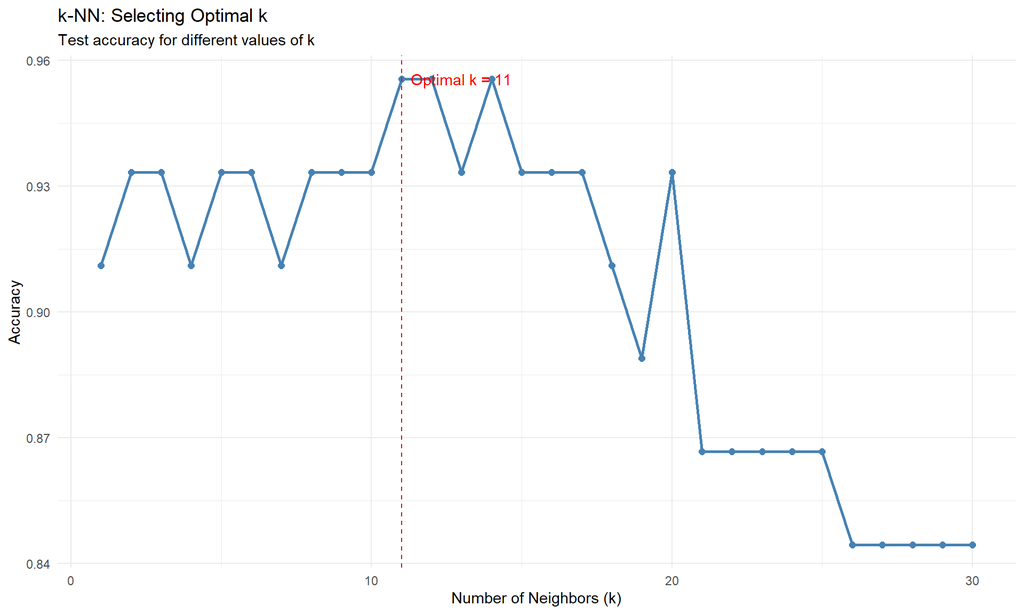

```r
# Evaluate different values of k
k_values <- 1:30
accuracy <- numeric(length(k_values))

for (i in seq_along(k_values)) {
  pred <- knn(train = train_scaled,
              test = test_scaled,
              cl = iris_train$Species,
              k = k_values[i])
  accuracy[i] <- mean(pred == iris_test$Species)
}

# Plot accuracy vs k
k_results <- data.frame(k = k_values, Accuracy = accuracy)

ggplot(k_results, aes(x = k, y = Accuracy)) +
  geom_line(color = "steelblue", linewidth = 1) +
  geom_point(color = "steelblue", size = 2) +
  geom_vline(xintercept = k_values[which.max(accuracy)],
             linetype = "dashed", color = "red") +
  annotate("text", x = k_values[which.max(accuracy)] + 2, y = max(accuracy),
           label = paste("Optimal k =", k_values[which.max(accuracy)]),
           color = "red") +
  labs(title = "k-NN: Selecting Optimal k",
       subtitle = "Test accuracy for different values of k",
       x = "Number of Neighbors (k)", y = "Accuracy") +
  theme_minimal()
```

```r
cat("Optimal k:", k_values[which.max(accuracy)], "\n")
```

```
## Optimal k: 11
```

```r
cat("Best accuracy:", max(accuracy), "\n")
```

```
## Best accuracy: 0.9555556
```

We could make the $k$ value comparison more reboust by using cross validation with each possible $k$ value. This can be controlled with the `tuneGrid` option when using `caret::train()`.

```r
# Set up cross-validation
ctrl <- trainControl(method = "cv", number = 10)

# Train k-NN with automatic k selection
knn_cv <- train(Species ~ .,
                data = iris_train,
                method = "knn",
                trControl = ctrl,
                preProcess = c("center", "scale"),
                tuneGrid = data.frame(k = 1:20))

# Results
print(knn_cv)
```

```
## k-Nearest Neighbors
##
## 105 samples
##   4 predictor
##   3 classes: 'setosa', 'versicolor', 'virginica'
##
## Pre-processing: centered (4), scaled (4)
## Resampling: Cross-Validated (10 fold)
## Summary of sample sizes: 95, 94, 95, 94, 95, 96, ...
## Resampling results across tuning parameters:
##
##   k   Accuracy   Kappa
##    1  0.9516162  0.9267578
##    2  0.9516162  0.9267578
##    3  0.9614646  0.9417578
##    4  0.9423737  0.9130824
##    5  0.9523737  0.9284037
##    6  0.9432828  0.9146537
##    7  0.9614646  0.9419839
##    8  0.9614646  0.9421580
##    9  0.9523737  0.9282339
##   10  0.9523737  0.9282339
##   11  0.9523737  0.9282339
##   12  0.9523737  0.9282339
##   13  0.9523737  0.9282339
##   14  0.9523737  0.9282339
##   15  0.9523737  0.9282339
##   16  0.9523737  0.9282339
##   17  0.9432828  0.9144839
##   18  0.9332828  0.8993324
##   19  0.9341919  0.9007339
##   20  0.9151010  0.8718324
##
## Accuracy was used to select the optimal model using the largest value.
## The final value used for the model was k = 8.
```

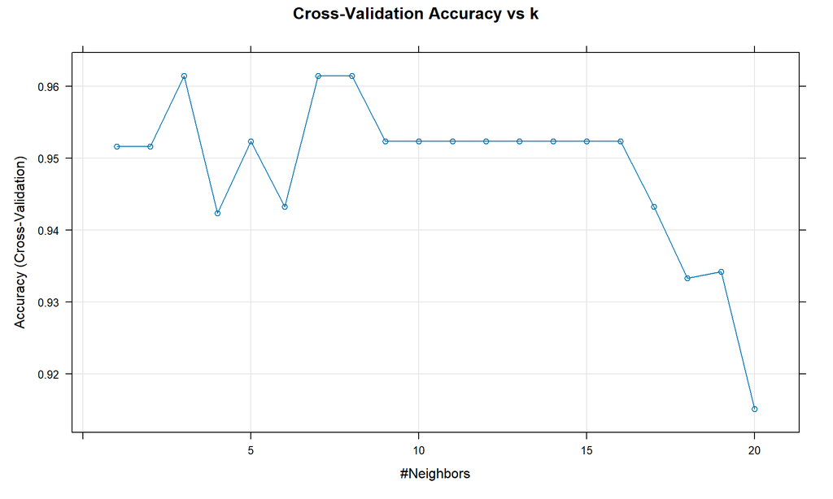

```r
plot(knn_cv, main = "Cross-Validation Accuracy vs k")
```

```r
# Best model predictions
knn_cv_pred <- predict(knn_cv, iris_test)
confusionMatrix(knn_cv_pred, iris_test$Species)
```

```
## Confusion Matrix and Statistics
##
##             Reference
## Prediction   setosa versicolor virginica
##   setosa         15          0         0
##   versicolor      0         14         3
##   virginica       0          1        12
##
## Overall Statistics
##
##                Accuracy : 0.9111
##                  95% CI : (0.7878, 0.9752)
##     No Information Rate : 0.3333
##     P-Value [Acc > NIR] : 8.467e-16
##
##                   Kappa : 0.8667
##
##  Mcnemar's Test P-Value : NA
##
## Statistics by Class:
##
##                      Class: setosa Class: versicolor Class: virginica
## Sensitivity                 1.0000            0.9333           0.8000
## Specificity                 1.0000            0.9000           0.9667
## Pos Pred Value              1.0000            0.8235           0.9231
## Neg Pred Value              1.0000            0.9643           0.9062
## Prevalence                  0.3333            0.3333           0.3333
## Detection Rate              0.3333            0.3111           0.2667
## Detection Prevalence        0.3333            0.3778           0.2889
## Balanced Accuracy           1.0000            0.9167           0.8833
```

# 3 k-Nearest Neighbors for Regression

k-NN can also predict continuous outcomes by averaging the target values of the nearest neighbors. Lets do an example where we predict `mpg` with `mtcars`

```r
data(mtcars)

# Train/test split
set.seed(456)
train_idx_reg <- createDataPartition(mtcars$mpg, p = 0.75, list = FALSE)
mtcars_train <- mtcars[train_idx_reg, ]
mtcars_test <- mtcars[-train_idx_reg, ]

cat("Training set:", nrow(mtcars_train), "cars\n")
```

```
## Training set: 25 cars
```

```r
cat("Test set:", nrow(mtcars_test), "cars\n")
```

```
## Test set: 7 cars
```

```r
# Cross-validation setup for regression
ctrl_reg <- trainControl(method = "repeatedcv", number = 5, repeats = 3)

# k-NN regression model
knn_reg <- train(
  mpg ~ wt + hp + disp + cyl,
  data = mtcars_train,
  method = "knn",
  trControl = ctrl_reg,
  preProcess = c("center", "scale"), # Scaling directly when training
  tuneGrid = data.frame(k = 1:15),
  metric = "RMSE"
)

print(knn_reg)
```

```
## k-Nearest Neighbors
##
## 25 samples
##  4 predictor
##
## Pre-processing: centered (4), scaled (4)
## Resampling: Cross-Validated (5 fold, repeated 3 times)
## Summary of sample sizes: 19, 20, 21, 20, 20, 20, ...
## Resampling results across tuning parameters:
##
##   k   RMSE      Rsquared   MAE
##    1  2.460805  0.8953849  1.904000
##    2  2.521897  0.8701782  2.081619
##    3  2.618575  0.8663511  2.204571
##    4  2.491323  0.8668223  2.117687
##    5  2.575347  0.8771236  2.161657
##    6  2.718859  0.8651159  2.265937
##    7  2.808037  0.8371702  2.310019
##    8  2.920941  0.8092616  2.408990
##    9  3.030466  0.7905806  2.576511
##   10  3.151383  0.7726511  2.688206
##   11  3.317970  0.7608853  2.784460
##   12  3.477088  0.7537835  2.852414
##   13  3.683953  0.7435348  2.972458
##   14  3.891499  0.7282195  3.099546
##   15  4.097603  0.7116752  3.255517
##
## RMSE was used to select the optimal model using the smallest value.
## The final value used for the model was k = 1.
```

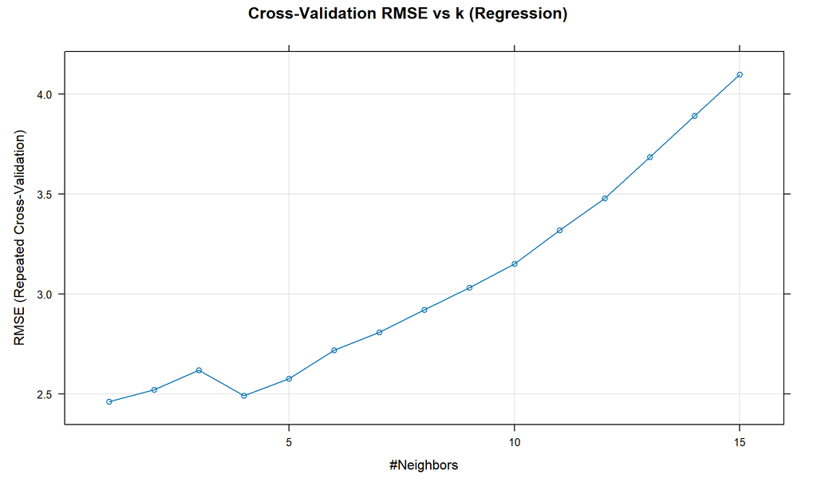

```r
plot(knn_reg, main = "Cross-Validation RMSE vs k (Regression)")
```

We can get some regression metrics, and also plot the observed vs obtained results, which should fall in the red diagonal line if the fit was perfect.

```r
# Test set predictions
knn_reg_pred <- predict(knn_reg, newdata = mtcars_test)

# Regression metrics
rmse_val <- RMSE(knn_reg_pred, mtcars_test$mpg)
mae_val <- MAE(knn_reg_pred, mtcars_test$mpg)
r2_val <- R2(knn_reg_pred, mtcars_test$mpg)

cat("Best k:", knn_reg$bestTune$k, "\n")
```

```
## Best k: 1
```

```r
cat("Test RMSE:", round(rmse_val, 3), "\n")
```

```
## Test RMSE: 3.031
```

```r
cat("Test MAE:", round(mae_val, 3), "\n")
```

```
## Test MAE: 2.371
```

```r
cat("Test R^2:", round(r2_val, 3), "\n")
```

```
## Test R^2: 0.851
```

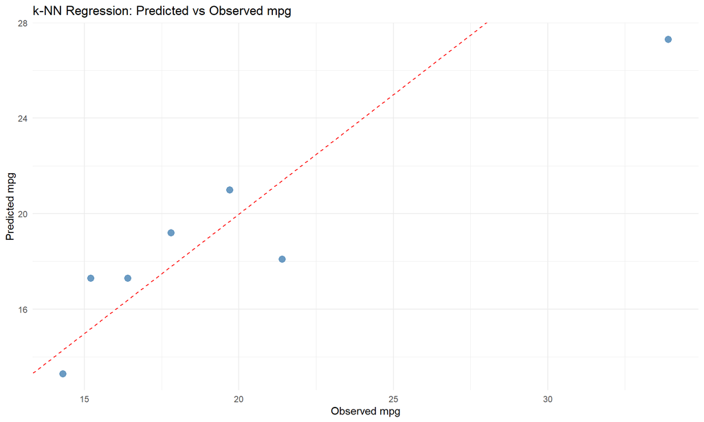

```r
reg_results <- tibble(
  observed = mtcars_test$mpg,
  predicted = knn_reg_pred
)

ggplot(reg_results, aes(x = observed, y = predicted)) +
  geom_point(size = 3, color = "steelblue", alpha = 0.8) +
  geom_abline(slope = 1, intercept = 0, linetype = "dashed", color = "red") +
  labs(title = "k-NN Regression: Predicted vs Observed mpg",
       x = "Observed mpg",
       y = "Predicted mpg") +
  theme_minimal()
```

If we want to visualize the **shape** of the KNN regression function (like a step curve), we can do it with a model fitted in 1D, using only one predictor, here `wt`.

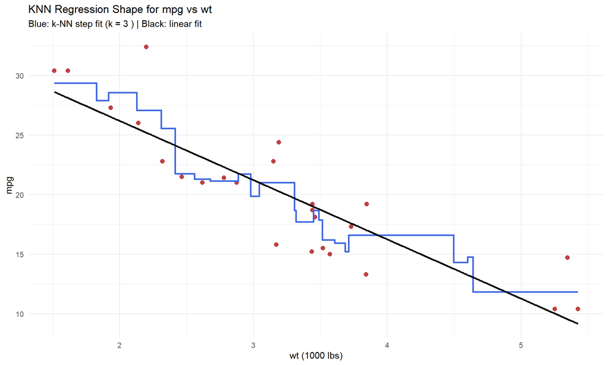

```r
# 1D model for visualization: mpg as a function of wt only
k_shape <- 3
knn_reg_wt <- train(
  mpg ~ wt,
  data = mtcars_train,
  method = "knn",
  trControl = ctrl_reg,
  preProcess = c("center", "scale"),
  tuneGrid = data.frame(k = k_shape),
  metric = "RMSE"
)

# Smooth grid over wt to draw the fitted function
wt_grid <- tibble(
  wt = seq(min(mtcars_train$wt), max(mtcars_train$wt), length.out = 300)
)

lm_wt <- lm(mpg ~ wt, data = mtcars_train)

plot_data <- wt_grid %>%
  mutate(
    mpg_knn = predict(knn_reg_wt, newdata = wt_grid),
    mpg_lm = predict(lm_wt, newdata = wt_grid)
  )

ggplot() +
  geom_point(data = mtcars_train, aes(x = wt, y = mpg),
             color = "firebrick", size = 2.2, alpha = 0.85) +
  geom_step(data = plot_data, aes(x = wt, y = mpg_knn),
            color = "royalblue", linewidth = 0.9) +
  geom_line(data = plot_data, aes(x = wt, y = mpg_lm),
            color = "black", linewidth = 1) +
  labs(
    title = "KNN Regression Shape for mpg vs wt",
    subtitle = paste("Blue: k-NN step fit (k =", k_shape, ") | Black: linear fit"),
    x = "wt (1000 lbs)",
    y = "mpg"
  ) +
  theme_minimal()
```